# Plot analysis on Jane Austen’s books

## Hooking it all together

```r
  result <- austen %>%
    mutate(linenumber = row_number(),
           chapter = cumsum(str_detect(text, regex("^chapter [\\divxlc]+", ignore_case = TRUE)))) %>%
  ungroup()

  result[12620:12630,]
```

```
## # A tibble: 11 x 4
##    text                                     book         linenumber chapter
##    <chr>                                    <fct>             <int>   <int>
##  1 between themselves, or producing coolne… Sense & Sen…      12620      50
##  2 ""                                       Sense & Sen…      12621      50
##  3 ""                                       Sense & Sen…      12622      50
##  4 ""                                       Sense & Sen…      12623      50
##  5 THE END                                  Sense & Sen…      12624      50
##  6 PRIDE AND PREJUDICE                      Pride & Pre…      12625      50
##  7 ""                                       Pride & Pre…      12626      50
##  8 By Jane Austen                           Pride & Pre…      12627      50
##  9 ""                                       Pride & Pre…      12628      50
## 10 ""                                       Pride & Pre…      12629      50
## 11 ""                                       Pride & Pre…      12630      50
```

This didn’t work. As you can see between rows 5 and 6, the linenumber and chapter count carries over to the next book. Ideally, we would want to ‘reset’ this counter in some sense for each new book. Alternatively, we could apply the operations we were doing on *each book in its own*. This is basically what group_by allows us to do. Grouping the dataframe by books before applying the operations means that the operations will be applied on each group (i.e each book) separately!

```r
  austen <- austen %>%
    group_by(book) %>%
    mutate(linenumber = row_number(),
           chapter = cumsum(str_detect(text, regex("^chapter [\\divxlc]+", ignore_case = TRUE)))) %>%
  ungroup()

  austen[12620:12630,]
```

```
## # A tibble: 11 x 4
##    text                                     book         linenumber chapter
##    <chr>                                    <fct>             <int>   <int>
##  1 between themselves, or producing coolne… Sense & Sen…      12620      50
##  2 ""                                       Sense & Sen…      12621      50
##  3 ""                                       Sense & Sen…      12622      50
##  4 ""                                       Sense & Sen…      12623      50
##  5 THE END                                  Sense & Sen…      12624      50
##  6 PRIDE AND PREJUDICE                      Pride & Pre…          1       0
##  7 ""                                       Pride & Pre…          2       0
##  8 By Jane Austen                           Pride & Pre…          3       0
##  9 ""                                       Pride & Pre…          4       0
## 10 ""                                       Pride & Pre…          5       0
## 11 ""                                       Pride & Pre…          6       0
```

Nice.

Now is a good time to decide how we will analyze the plot in the stories. In this notebook, we will try to categorize the plot in each chapter as either “mostly positive” or “mostly negative”. To do this, we could use some of the sentiment dictionaries available in R. These dictionaries map each word to a sentiment. The dictionary we will be using (trained on data from search engine Bing) classifies each word as either positive or negative.

Since the dictionary we will be using operates on words, we will have to tokenize the text we have from lines into words.

```r
library(tidytext)  # gives us unnest_tokens

# split line in text into words and store result in new column called 'word'
austen_tokens <- austen %>% unnest_tokens(word, text)
```

If we look at the most frequent words in our dataset,

```r
austen_tokens %>% count(word) %>% arrange(desc(n))
```

```
## # A tibble: 14,520 x 2
##    word      n
##    <chr> <int>
##  1 the   26351
##  2 to    24044
##  3 and   22515
##  4 of    21178
##  5 a     13408
##  6 her   13055
##  7 i     12006
##  8 in    11217
##  9 was   11204
## 10 it    10234
## # … with 14,510 more rows
```

This isn’t very insightful. Words like ‘the’, ‘to’ and ‘a’ are called “stop-words”. They are the most common words in a language and are usually useless when it comes to natural language processing. It would be a good idea to get rid of these.

To do it, we will use a pre-compiled list of stop-words that is available in R. Therefore, we will just remove all words in our list that are present in the stop-words list. This operation is called ‘anti-join’. Below is a diagram that represents how anti-join works.

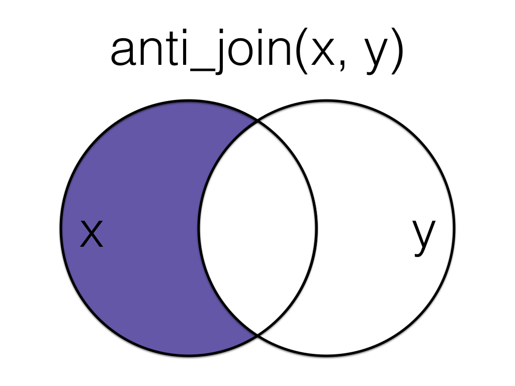

```r
tidy_austen <- austen_tokens %>% anti_join(get_stopwords(), by='word')
tidy_austen %>% count(word) %>%
  arrange(desc(n))
```

```
## # A tibble: 14,375 x 2
##    word      n
##    <chr> <int>
##  1 mr     3015
##  2 mrs    2446
##  3 must   2071
##  4 said   2041
##  5 much   1935
##  6 miss   1855
##  7 one    1831
##  8 well   1523
##  9 every  1456
## 10 think  1440
## # … with 14,365 more rows
```

Much better. However, we still notice some words like “mr”, “mrs” and “miss” that, while potentially useful for other analyses, do not have much value for the task we want to achieve. Let’s add them to our dictionary of stopwords and remove them using the same method we used before.

```r
# Our custom stopwords dataframe must abide by stopword dictionary standards and include two columns:
#word and lexicon. Since we are adding the words ourselves, the value in lexicon should be "custom" for each word.
extra_stop_words <- tibble(word = c("miss", "mrs", "mr", "mister", "sir"),
                           lexicon = c("custom", "custom","custom", "custom", "custom"))
stop_words <- get_stopwords()

# create a new dataframe by stacking the original stop_words dataframe with our custom one.
custom_stop_words <- bind_rows(extra_stop_words, stop_words)

tidy_austen <- austen_tokens %>% anti_join(custom_stop_words, by='word')
tidy_austen %>% count(word) %>%
  arrange(desc(n))
```

```
## # A tibble: 14,371 x 2
##    word      n
##    <chr> <int>
##  1 must   2071
##  2 said   2041
##  3 much   1935
##  4 one    1831
##  5 well   1523
##  6 every  1456
##  7 think  1440
##  8 now    1405
##  9 good   1380
## 10 might  1369
## # … with 14,361 more rows
```

Great. Now that we have a clean list of words, let us move to sentiment analysis!

## Sentiment analysis on each chapter

As mentioned previously, we will be using the “bing” sentiment dictionary to classify each word as conveying either “positive” or “negative” sentiments.

```r
bing_sentiments <- get_sentiments("bing")
head(bing_sentiments)
```

```
## # A tibble: 6 x 2
##   word       sentiment
##   <chr>      <chr>
## 1 2-faces    negative
## 2 abnormal   negative
## 3 abolish    negative
## 4 abominable negative
## 5 abominably negative
## 6 abominate  negative
```

bing_sentiments is basically just a list of words and a column ‘sentiment’ that classifies the word as either negative or positive. Some of our words will appear in bing_sentiments. For those, we would like to classify them with the sentiment they are assigned in bing_sentiments. To do this, we will use a different kind of join: inner_join. inner_join only only keeps the words that appear in both our corpus and bing_sentiments and merges the columns together (adds the column sentiments to the columns book and word).

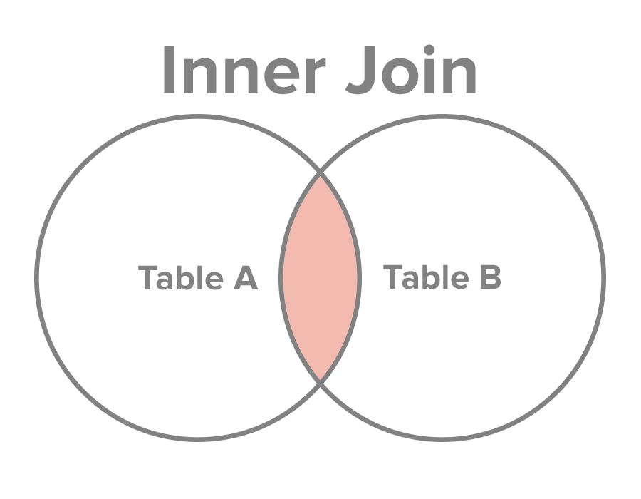

Here are the results we get:

```r
austen_sentiments <- tidy_austen %>% inner_join(bing_sentiments, by='word')

head(austen_sentiments)
```

```
## # A tibble: 6 x 5
##   book                linenumber chapter word        sentiment
##   <fct>                    <int>   <int> <chr>       <chr>
## 1 Sense & Sensibility         16       1 respectable positive
## 2 Sense & Sensibility         16       1 good        positive
## 3 Sense & Sensibility         18       1 advanced    positive
## 4 Sense & Sensibility         20       1 death       negative
## 5 Sense & Sensibility         20       1 great       positive
## 6 Sense & Sensibility         21       1 loss        negative
```

Now, let’s count the number of positive/negative words we have in each chapter and book.

```r
# We count the number of unique values of (book, chapter, sentiment) to get the number
# of positive/negative words in each chapter in each book.
austen_sentiments <- austen_sentiments %>% count(book, chapter, sentiment)
head(austen_sentiments)
```

```
## # A tibble: 6 x 4
##   book                chapter sentiment     n
##   <fct>                 <int> <chr>     <int>
## 1 Sense & Sensibility       1 negative     35
## 2 Sense & Sensibility       1 positive     86
## 3 Sense & Sensibility       2 negative     30
## 4 Sense & Sensibility       2 positive     76
## 5 Sense & Sensibility       3 negative     41
## 6 Sense & Sensibility       3 positive     98
```

Great! As a next step, let’s calculate an overall sentiment score for each chapter in each book. To do this, we could simply subtract the number of negative words from then number of negative words.

As you can notice, every chapter in every book has two rows: one row showing the number of positive words and another showing the number of negative words. Let’s merge these two rows for every chapter in every story into one row with two columns: number of positive words and number of negative words. To do this, we can use the method spread():

```r
library(tidyr)  # gives us spread()

# We spread the values of sentiment (positive or negative) into two columns and fill them with their values of 'n' (the count).
# If one chapter does not have any positive words, we fill its positive column by 0 (hence the fill=0).
austen_sentiments <- austen_sentiments %>% spread(sentiment, n, fill = 0)
head(austen_sentiments)
```

```
## # A tibble: 6 x 4
##   book                chapter negative positive
##   <fct>                 <int>    <dbl>    <dbl>
## 1 Sense & Sensibility       1       35       86
## 2 Sense & Sensibility       2       30       76
## 3 Sense & Sensibility       3       41       98
## 4 Sense & Sensibility       4       64      103
## 5 Sense & Sensibility       5       20       24
## 6 Sense & Sensibility       6       20       67
```

```r
# calculate overall sentiment
austen_sentiments <- austen_sentiments %>% mutate(sentiment = positive - negative)
head(austen_sentiments)
```

```
## # A tibble: 6 x 5
##   book                chapter negative positive sentiment
##   <fct>                 <int>    <dbl>    <dbl>     <dbl>
## 1 Sense & Sensibility       1       35       86        51
## 2 Sense & Sensibility       2       30       76        46
## 3 Sense & Sensibility       3       41       98        57
## 4 Sense & Sensibility       4       64      103        39
## 5 Sense & Sensibility       5       20       24         4
## 6 Sense & Sensibility       6       20       67        47
```

Perfect. Our dataframe looks exactly as we wanted it to be. Each chapter has a sentiment score that represents the dominating sentiment. All what is left is to plot the result and enjoy!

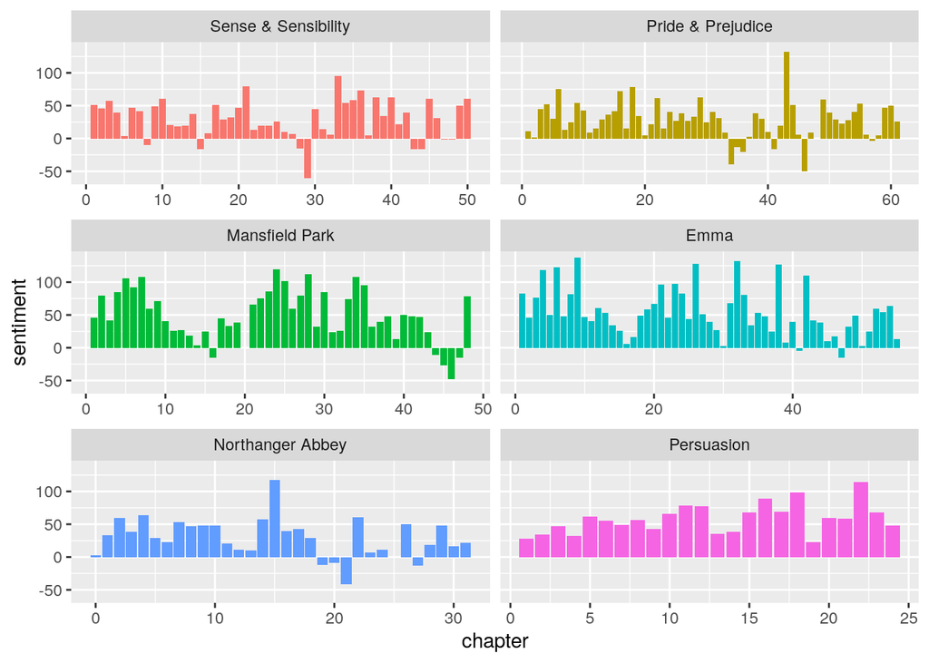

```r
ggplot(austen_sentiments, aes(x=chapter, y=sentiment,fill=book)) +
  geom_col(show.legend = F) +
  facet_wrap(~book,ncol=2, scales="free_x")
```

Notice the sudden plot twist at the end of Mansfield Park! Persuasion seems like a nice bedtime story. Pride and Prejudice explains well the phrase ‘rollercoaster of emotions’.

That was it! This exercise was adapted from https://www.tidytextmining.com/sentiment.html To keep things simple, we omitted some really cool stuff from the article so please take a look at it!